# 04_segmentation

## Segmentation

Segmentation is a common image processing task that results in object rather than image information. Segmentation can involve multiple filters and algorithms or can be as simple as thresholding the image and finding contiguous regions. In the following, we will look at a simple but common approach and then explore some more sophisticated image segmentation methods.

First, we again need modules for image import and plotting.

```python
# the basics
from skimage.io import imread
import numpy as np
from matplotlib import pyplot as plt
from glob import glob
import os
# for inline plotting and fun with dynamic plots
%matplotlib inline
from ipywidgets import interact, interactive, fixed
```

We will start from image thresholding, so let's import these functions again as well.

```python
# filters to enhance or attenuate image details
from skimage.filters import gaussian, median, threshold_otsu
# morphological filters
from skimage.morphology import closing, dilation, erosion, opening, remove_small_holes, remove_small_objects
# a structure element
from skimage.morphology import disk
```

Let's read the image data.

```python
image_files = sorted(glob('../sample_data/*.tiff'))
image = imread(image_files[0])
channel_0 = image[:,:,0]
channel_1 = image[:,:,1]
```

Let's go through our image processing steps so far.

- First, let's gaussian blur the original image (here the DNA channel)
- Then, let's apply the Otsu threshold to obtain a binary image.
- Remove small holes and small objects.
- Apply a morphological opening to separate touching cells.

```python
Gauss = gaussian(channel_1, sigma=5)
Thresholded = Gauss > threshold_otsu(Gauss)
Holes_removed = remove_small_holes(Thresholded, area_threshold = 512)
Small_objects_removed = remove_small_objects(Holes_removed, min_size = 1024)
Opened_binary = opening(Small_objects_removed, disk(13))
```

Let's have a look how the cells are labeled.

```python
from skimage.segmentation import find_boundaries
from skimage.color import label2rgb
```

```python
from skimage.morphology import label
from skimage.exposure import rescale_intensity
```

These functions find the boundaries in a binaray image, label individual contiguous regions, and generate overlay images for quick display. `rescale_intensity` is used to adjust the brightness of the original image.

```python
Boundaries = find_boundaries(Opened_binary)
Labels = label(Opened_binary)
Overlay = label2rgb(Labels, image=rescale_intensity(channel_1), bg_label=0)
Overlay_Boundaries = label2rgb(dilation(Boundaries), image=rescale_intensity(channel_1, in_range=(400,4000)), bg_label=0)
```

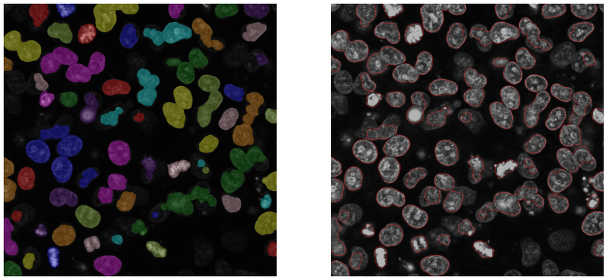

```python
fig, ax = plt.subplots(1,2,figsize=(20,10))
ax[0].imshow(Overlay, vmin=0, vmax=10)
ax[0].axis('off')
ax[1].imshow(Overlay_Boundaries, vmin=0, vmax=10)
ax[1].axis('off');
```

As you can see, there are still many touching cells that are receiving the same label. Can we do better than that?

### Watershed

The Watershed is a frequently used algorithm to separate touching objects. To apply Watershed in scikit-image, we need some more modules. Some of them are from the `scipy` library.

```python
from scipy.ndimage.morphology import distance_transform_edt
from scipy import ndimage as ndi
from skimage.feature import peak_local_max
from skimage.segmentation import watershed
```

The Watershed is effective in separating objects but prone to over-segmentation. We need to give the algorithm some 'orientation'. Often, the distance transform is used to find markers for the Watershed. Execute the next cell to do the following:

- Generate a distance transform image from the thresholded image.
- Find local maxima and generate a marker image.
- Run the watershed on the inverse distance transform `-DT` using our markers.

The result is a 'label' image where each identified object gets a different number.

```python
DT = distance_transform_edt(Small_objects_removed)
Coords = peak_local_max(DT, labels=Small_objects_removed, min_distance=25) # adjust the minimum distance depending on cell size / pixel size
Mask = np.zeros(DT.shape, dtype=bool)
Mask[tuple(Coords.T)] = True
Mask = dilation(Mask, disk(5))
Markers, _ = ndi.label(Mask)
Labels = watershed(-DT, Markers, mask=Small_objects_removed)
```

```python
from mpl_toolkits.mplot3d import Axes3D
```

```python
DT_copy = DT
DT_copy[DT_copy < 0] = 0 # set negativce values to zero
```

```python
%matplotlib widget
fig = plt.figure(figsize=(10,10))
ax = fig.add_subplot(projection='3d')
xx, yy = np.mgrid[0:DT.shape[0], 0:DT.shape[1]]
ax.plot_surface(xx, yy, -DT_copy.astype(int), rstride=10, cstride=10, linewidth=0, cmap='gray')
plt.show()
```

[output not shown]

Here a plot of the distance transform and the markers that are generated from the local maxima of the distance transform.

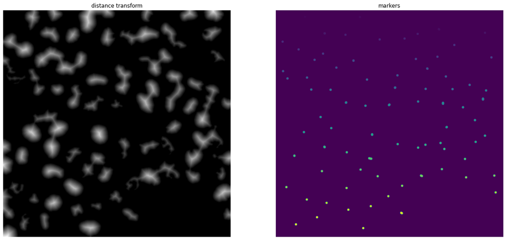

```python
fig, ax = plt.subplots(1,2,figsize=(20,10))
ax[0].imshow(DT, cmap='gray')
ax[0].axis('off')
ax[0].set_title('distance transform')
ax[1].imshow(Markers)
ax[1].axis('off')
ax[1].set_title('markers')
```

Finally, let's have look at the labels that the Watershed generated.

```
(-0.5, 1023.5, 1023.5, -0.5)
```

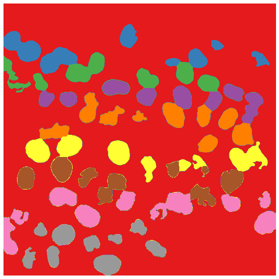

```python
fig, ax = plt.subplots(1,1,figsize=(10,10))
ax.imshow(Labels, cmap='Set1')
ax.axis('off')
```

This goes in the right direction! Now, more cells are separated. Another flavor of the Watershed uses a **gradient filter** to find the outline of cells and uses it as 'dams' for the algorithm. We will compare these flavors of Watershed and other segmentation approaches in the homework exercise.

### Evaluating segmentation results

When setting up a new segmentation pipeline, it is important to test how good the segmentation is. This is frequently done with a 'ground truth', a segmentation that is considered optimal. A real ground truth can only be established from synthetic data - images that are artificially generated and then changed in a way that a microscope would (addition of simulated noise, aberrations etc.). If we want to obtain ground truth from real world images, the best we can often (unfortunately) only do is label the images by hand, i.e. draw regions around cells and mark them as 'foreground'.

Let's test the Watershed on an image where we drew some masks by hand, and compare to our manual segmentation.

```python
test_image_files = sorted(glob('../evaluation_data/images/*.tiff'))
test_image = imread(test_image_files[0])
test_mask_files = sorted(glob('../evaluation_data/masks/*.tiff'))
test_mask = imread(test_mask_files[0])
```

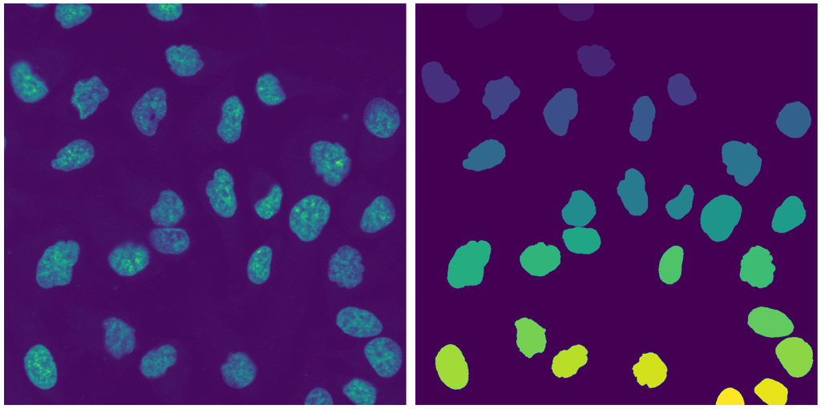

```python
fig, ax = plt.subplots(1,2,figsize=(20,10))
ax[0].imshow(test_image)
ax[0].axis('off')
ax[1].imshow(test_mask)
ax[1].axis('off')
plt.tight_layout()
```

Let's run the pipeline that we have so far.

```python
Gauss = gaussian(test_image, sigma=5)
Thresholded = Gauss > threshold_otsu(Gauss)
Holes_removed = remove_small_holes(Thresholded, area_threshold = 512)
Small_objects_removed = remove_small_objects(Holes_removed, min_size = 1024)
DT = distance_transform_edt(Small_objects_removed)
Coords = peak_local_max(DT, labels=Small_objects_removed, min_distance=25) # adjust the minimum distance depending on cell size / pixel size
Mask = np.zeros(DT.shape, dtype=bool)
Mask[tuple(Coords.T)] = True
Mask = dilation(Mask, disk(5))
Markers, _ = ndi.label(Mask)
Labels = watershed(-DT, Markers, mask=Small_objects_removed)
```

Let's compare the result to the manual annotation.

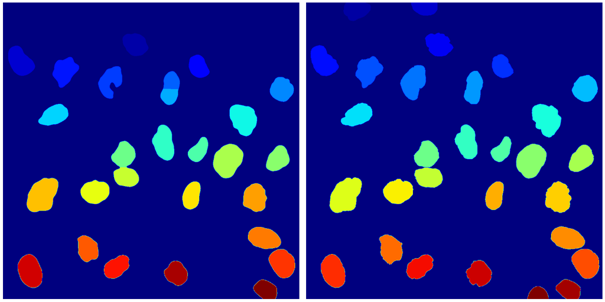

```python
fig, ax = plt.subplots(1,2,figsize=(20,10))
ax[0].imshow(Labels, cmap='jet')
ax[0].axis('off')
ax[1].imshow(test_mask,  cmap='jet')
ax[1].axis('off')
plt.tight_layout()
```

We can see that the Watershed did well, but *how well* did it do? A measurement for that is the intersect over union (IOU).

```python
result1 = Labels > 0
result2 = test_mask > 0
intersection = np.logical_and(result1, result2)
union = np.logical_or(result1, result2)
iou_score = np.sum(intersection) / np.sum(union)
```

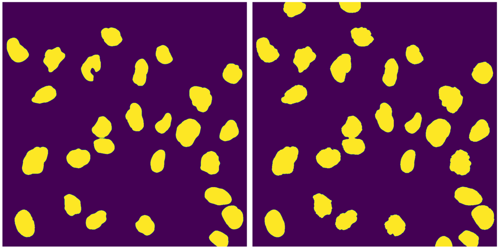

```python
fig, ax = plt.subplots(1,2,figsize=(20,10))
ax[0].imshow(intersection)
ax[0].axis('off')
ax[1].imshow(union)
ax[1].axis('off')
plt.tight_layout()
```

```python
print("IOU score is {:4f}".format(iou_score))
```

```
IOU score is 0.860047
```

In this example, the Watershed did not detect some cells at the image border, but we still get a 86% overlap with the hand annotated image. Not bad for a (cumulative) few lines of code! However, this example was relatively 'easy' as the cells were nicely spaced and we would probably also get a good results by only thresholding the image.